# Review for IFDP substrate Prediction Method

Ved Piyush

2/6/2023

# Summary

1. IFDP method is using different naming conventions for their `high_level_substrates`. Only $42.30\%$ of the `high_level_substrates` from the experimentally verified PUL `high_level_substrates` share the same naming convention with IFDP (after lower casing). For the rest of the `high_level_substrates` that do not appear in the IFDP predictions, we would need a mapping so we can map the `high_level_substrates` from the experimentally verified PUL data to IFDP `high_level_substrates`.
2. If we just analyze the PULs corresponding to the $42.30\%$ `high_level_substrates`that share the same name we cover almost $55.96\%$ of the PULs that we have in the experimentally verified PUL data.
3. IFDP method predicts the relative abundance of the high level substrates in the PULs and this relative abundance is like a score. We can consider this as the probability score that is outputted from the subFinder pipeline. Just as we take the `high_level_substrates` corresponding to the maximum probability as the predicted substrate from subFinder, we can consider the `high_level_substrates` with maximum relative abundance from IFDP as the predicted `high_level_substrates` for that PUL.
4. However, their method has a lot of ties and a definitive prediction of the `high_level_substrates` for a PUL is next to impossible for majority of the PULs. The bar plot below shows the number of PULs corresponding to the number of `high_level_substrates` predicted from IFDP method. For example, for only 69 out of the 230 PULs from (2) have a single definitive prediction for the high level substrate which amounts to an abysmally low $30\%$. The IFDP method sometimes even gives 11 predicted `high_level_substrates`.

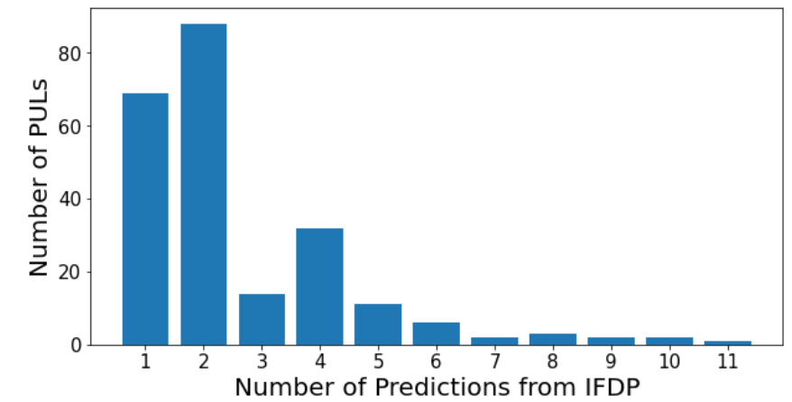

5. First, IFDP due to the nature of giving multiple `high_level_substrates` predictions, we cannot make a definite prediction for $70\%$ of the PULs from (2). For the rest $30\%$ of the PULs on which there is a single definitive prediction of the `high_level_substrates` from IFDP, their prediction matches the ground truth experimentally verified `high_level_substrates` a meager $42.02\%$.

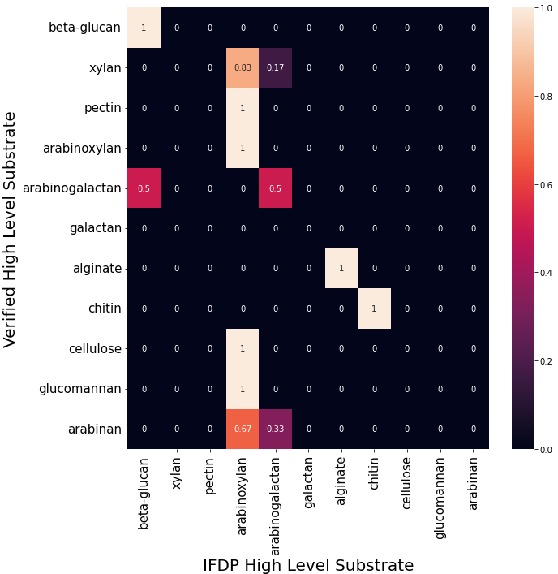